# Quantification of Quality of Personal Activity

Srinivas Chakravarty

15 May, 2016

## 1. Background

It is possible to collect a large amount of data about personal activity relatively inexpensively, by using devices such as Jawbone Up, Nike FuelBand, and Fitbit. While people regularly quantify how much of a particular activity they do, they rarely quantify how well they do it.

This project quantifies how 6 participants performed barbell lifts by analyzing data from accelerometers on the belt, forearm, arm, and dumbell of those participants.

## 2. Approach

In order to quantify the performance of the participants, the following steps were followed -

1. Download the data provided in the datasets *pml-training.csv* and *pml-testing.csv*.
2. Cleanse the data in the two datasets.
3. Slice the cleansed training data into *Training* and *Validation* datasets (75 : 25).
4. Develop the *Prediction Model* with *Random Forests* against the *Training* dataset.
5. Measure the *Prediction Model* against the *Validation* dataset.
6. Use the *Prediction Model* to make predictions against the *Testing* dataset.

## 3. Data Management

```r
# Load libraries as needed

pkgsNeeded <- c ("caret", "rpart", "rpart.plot")
sapply (pkgsNeeded, library, character.only = TRUE)
```

```r
# Load Training and Test Data into Data Frames

trainUrlName <-"https://d396qusza40orc.cloudfront.net/predmachlearn/pml-training.csv"
testUrlName <- "https://d396qusza40orc.cloudfront.net/predmachlearn/pml-testing.csv"

trainData <- "./pml-training.csv"
testData <- "./pml-testing.csv"

if (!file.exists(trainData)) {
  download.file(trainUrlName, destfile=trainData)
}
if (!file.exists(testData)) {
  download.file(testUrlName, destfile=testData)
}

fullTrainDF <- read.csv("./pml-training.csv")
fullTestDF <- read.csv("./pml-testing.csv")

noImpactCols <- grep("^X$|user_name|timestamp|window", names(fullTrainDF))
retainCols <- colnames(fullTrainDF[colSums(is.na(fullTrainDF)) == 0])[-noImpactCols]

reducedTrainDF <- data.frame(
  (fullTrainDF[retainCols])[, sapply(fullTrainDF[retainCols], is.numeric)],
  fullTrainDF["classe"])

testData <- fullTestDF[colnames(reducedTrainDF)[1:length(colnames(reducedTrainDF)) - 1]]


# Split Data into Training and Validation Datasets

library(caret)
set.seed(as.integer(.Machine$integer.max))

inTrainData <- createDataPartition(y = reducedTrainDF$classe, p = 0.75, list = FALSE)
trainingData <- reducedTrainDF[inTrainData, ]
validationData <- reducedTrainDF[-inTrainData, ]
```

## 4. Prediction Model

As Ned Horning (Ref: Random Forests - An algorithm for image classification and generation of continuous fields data sets at http://http://wgrass.media.osaka-cu.ac.jp/gisideas10/papers/04aa1f4a8beb619e7fe711c29b7b.pdf) points out,

“Performance of random forests is on par with other machine learning algorithms but it is much easier to use and more forgiving with regard to over fitting and outliers than other algorithms”.

The Random Forests algorithm has therefore been utilised with 10 folds of cross-validation to predict the performance of the participants.

```r
modelRF <- train(classe ~ ., method = "rf", data = trainingData, importance = TRUE,
                 trControl = trainControl(method = "cv", number = 10))

print(modelRF)

predictRF <- predict(modelRF, newdata = validationData)
confusionMatrix(validationData$classe, predictRF)

classeAccuracy <- confusionMatrix(validationData$classe, predictRF)$overall[1]
```

[output not shown]

```r
paste0("Using Validation Data, Accuracy of ", round(classeAccuracy * 100, 2), "%",
       " was obtained with associated Out of Sample Error of ",
       round(100 - classeAccuracy * 100, 2), "%")
```

```
   [1] "Using Validation Data, Accuracy of 99.14% was obtained with associated Out of Sample Error of 0.86%"
```

## 5. Predictions On Test Data

The *Prediction Model* is now used against the *Test Data* to predict the outcomes for each of the observations.

```r
testPredictions <- predict(modelRF, newdata = testData)
print(testPredictions)
```

[output not shown]

```r
# Write Predictions to File

pmlPredictionsToFile = function(x){

  dir.create(file.path("./predictions"), showWarnings = FALSE)
  filename <- paste0("./predictions/predictionsML.txt")
  predictionsML = ""

  for(i in 1 : (length(x)-1)){
    predictionsML <- paste0(predictionsML, x[i], ", ")
  }

  predictionsML <- paste0(predictionsML, "and ", x[length(x)])

  write.table(predictionsML, file = filename, quote = FALSE, row.names = FALSE,
              col.names = FALSE)
 }

pmlPredictionsToFile(testPredictions)
```

The 20 predictions are written to *./predictions/predictionsML.txt*.

## 6. Conclusion

Given the high observed accuracy on the *Validation Data*, it was expected that the predictions on the *Test Data* would be very accurate as well.

## 7. Appendix

### 7.1 Accuracy Plot

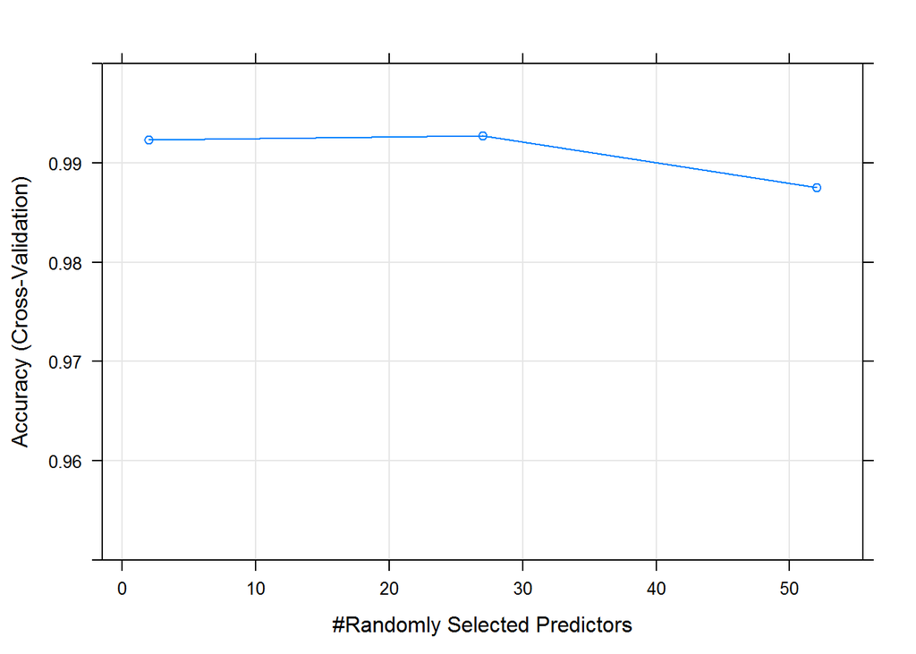

### 7.2 Decision Tree Diagram

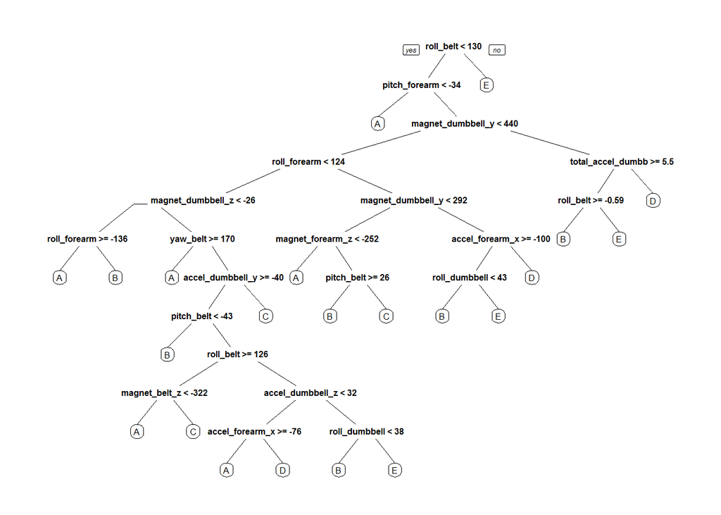

```r
decisionTreeDiagram <- rpart(classe ~ ., data = trainingData, method = "class")
prp(decisionTreeDiagram)
```

## 8. Acknowledgements

The data used in this project has been made available by -

Ugulino, W.; Cardador, D.; Vega, K.; Velloso, E.; Milidiu, R.; Fuks, H. Wearable Computing: Accelerometers’ Data Classification of Body Postures and Movements. Proceedings of 21st Brazilian Symposium on Artificial Intelligence. Advances in Artificial Intelligence - SBIA 2012. In: Lecture Notes in Computer Science. , pp. 52-61. Curitiba, PR: Springer Berlin / Heidelberg, 2012. ISBN 978-3-642-34458-9. DOI: 10.1007/978-3-642-34459-6_6.

Read more: http://groupware.les.inf.puc-rio.br/har#ixzz48hOT7VWz